# STAT 435 HW2

Chongyi Xu

April 12, 2018

1. Suppose we have a quantitative response $Y$, and a single feature $X\leq \mathbb{R}$. Let $RSS_1$ denote the residual sum of squares that results from fitting the modedl
   $$Y = \beta_0 + \beta_1X + \epsilon$$
   using least squares. Let $RSS_{12}$ denote the residual sum of squares that results from fitting the model
   $$Y = \beta_0 + \beta_1X + \beta_2X^2 + \epsilon$$
   using least squares.
1. Prove that $RSS_{12} \leq RSS_1$.

Denote $RSS$ to be the residual sum of squares. The method of least squares fitting is to minimize $RSS$.

2. Prove that $R^2$ of the model containing just the feature $X$ is no greater than the $R^2$ of the model containing both $X$ and $X^2$.

Since from part(a), we have concluded that $RSS_{12} \leq RSS_1$. And $R^2$ is definded to be $R^2 = 1 - \frac{RSS}{TSS}$
$$\begin{aligned}
R_1^2 &= 1 - \frac{RSS_1}{TSS} \\
R_{12}^2 &= 1 - \frac{RSS_{12}}{TSS}
\end{aligned}$$

$TSS$ are the same to two $R^2$ since they are from the same response $Y$.

$$RSS_{12} \leq RSS_1\Rightarrow 1 - \frac{RSS_1}{TSS} \leq 1 - \frac{RSS_{12}}{TSS} \Rightarrow R_1^2 \leq R_{12}^2$$

2. Describe the null hypotheses to which the p-value in Table 3.4 of the text book correspond. Explain what conclusion you can draw based on these p-values. Your explanation should be phrased in term of `sales`, `TV`, `radio`, and `newspaper`.
- `TV`
- $H_0$: The sales is not related with TV advertising.
- $H_1$: The sales is related with TV advertising.

From the p-value we found in Table 3.4 for TV ($p-value<0.0001$), it indicates strong evidence against the null hypothesese, the null hypothese is rejected, in the other word, the sales is related with TV advertising.

- `radio`
- $H_0$: The sales is not related with radio advertising.
- $H_1$: The sales is related with radio advertising.

From the p-value we found in Table 3.4 for radio ($p-value<0.0001$), it indicates strong evidence against the null hypothesese, the null hypothese is rejected, in the other word, the sales is related with radio advertising.

- `newspaper`
- $H_0$: The sales is not related with newspaper advertising.
- $H_1$: The sales is related with newspaper advertising.

From the p-value we found in Table 3.4 for radio ($p-value=0.8599$), it indicates that there is no sufficient evidence that supports rejecting the null hypotheses with a level of $\alpha=0.01$, the rejection fails. In the other word, we can not reject the hypotheses that there is no relationship between newpaper advertising and sales.

3. Consider a linear model with just one feature.

$$Y = \beta_0 + \beta_1X +\epsilon$$

Suppose we have $n$ observations from this model, $(x_1,y_1),\cdots,(x_n,y_n)$. The least squares estimators is given in (3.4) of the textbook. Furthermore, we saw in class that if we construct a n x 2 matrix $\tilde{\mathbf{X}}$. If we let $\mathbf{y}$ denote the vector with elements $y_1,\cdots,y_n$, then the least squares estimator takes the form

$$\binom{\hat{\beta_0}}{\hat{\beta_1}} = (\tilde{\mathbf{X}}^T\tilde{\mathbf{X}})^{-1}\tilde{\mathbf{X}}^T\mathbf{y}$$

Prove that the equation agrees with equation (3.4) of the textbook.

Consider the bottom of $\frac{1}{n\sum x_i^2 - (\sum x_i)^2}$, use that $\sum x_i = n\bar{x}$

$$\begin{aligned}
n\sum x_i^2 - (\sum x_i)^2 &= n\sum x_i^2 - n^2\bar{x}^2 \\
&= n^2(\frac{1}{n}\sum x_i^2 - \bar{x}^2) \\
&= n^2\frac{1}{n}(\sum x_i^2 - 2n\bar{x}\bar{x} + n\bar{x}^2) \\
&= n^2\frac{1}{n}(\sum x_i^2 - 2x_i\bar{x} + \bar{x}^2) \\
&= n\sum(x_i - \bar{x})^2
\end{aligned}$$

Now consider the second row of summation part($\beta_1$). We know that $n\bar{x}\bar{y} = \bar{x}\sum_{i} y_i = \bar{y}\sum_{i} x_i$

$$\begin{aligned}
\sum_{j=1}^n (- y_j\sum x_i + nx_jy_j) &= \sum_{j=1}^n (nx_jy_j - n\bar{x}y_j) \\
&= n(\sum_{j} x_jy_j - \bar{x}\sum_{j} y_j) \\
&= n(\sum_{j} x_jy_j - \bar{x}\sum_{j} y_j + n\bar{x}\bar{y} - \bar{y}\sum_{j} x_j) \\
&= n\sum_j(x_jy_j -\bar{y}x_j - \bar{x}y_j + \bar{x}\bar{y}) \\
&= n\sum_{j=1}^n (x_j-\bar{x})(y_j-\bar{y})
\end{aligned}$$

Therefore,

$$\beta_1 = \frac{n\sum_{j=1}^n (x_j-\bar{x})(y_j-\bar{y})}{n\sum(x_i - \bar{x})^2} = \frac{\sum_{j=1}^n (x_j-\bar{x})(y_j-\bar{y})}{\sum(x_i - \bar{x})^2} = \hat{\beta_1}$$

Now consider the first row of summation part($\beta_0$). We want to check if $\beta_0 = \bar{y} - \beta_1\bar{x}$

$$\begin{aligned}
\frac{\sum_{j=1}^n (y_j\sum x_i^2 - x_jy_j\sum x_i)}{n\sum(x_i - \bar{x})^2} &=
\frac{\sum_j (y_j\sum x_i^2)}{n\sum(x_i - \bar{x})^2} - \frac{\sum_j (x_jy_j\sum x_i)}{n\sum(x_i - \bar{x})^2}
\\
&= \frac{n\bar{y}\bar{x^2}}{\sum(x_i - \bar{x})^2} - \frac{\bar{x}\sum_j x_jy_j}{\sum(x_i - \bar{x})^2} \\
&= \bar{y} - \beta_1 \bar{x}\\
&\beta_0 = \bar{y} - \beta_1\bar{x}(QED)
\end{aligned}$$

4. This question involves the use of multiple linear regression on the Auto data set.
1. Use the `lm()` function to perform a multiple linear regression with `mpg` as the response and all other variables except `name` as the predictors.

```r
library(ISLR)
dat <- Auto
dat$origin.f <- factor(dat$origin,labels=c('American','European','Japanese'))

model.fit <- lm(data=dat, mpg~. - name - origin)

summary(model.fit)
```

```
##
## Call:
## lm(formula = mpg ~ . - name - origin, data = dat)
##
## Residuals:
##     Min      1Q  Median      3Q     Max
## -9.0095 -2.0785 -0.0982  1.9856 13.3608
##
## Coefficients:
##                    Estimate Std. Error t value Pr(>|t|)
## (Intercept)      -1.795e+01  4.677e+00  -3.839 0.000145 ***
## cylinders        -4.897e-01  3.212e-01  -1.524 0.128215
## displacement      2.398e-02  7.653e-03   3.133 0.001863 **
## horsepower       -1.818e-02  1.371e-02  -1.326 0.185488
## weight           -6.710e-03  6.551e-04 -10.243  < 2e-16 ***
## acceleration      7.910e-02  9.822e-02   0.805 0.421101
## year              7.770e-01  5.178e-02  15.005  < 2e-16 ***
## origin.fEuropean  2.630e+00  5.664e-01   4.643 4.72e-06 ***
## origin.fJapanese  2.853e+00  5.527e-01   5.162 3.93e-07 ***
## ---
## Signif. codes:  0 '***' 0.001 '**' 0.01 '*' 0.05 '.' 0.1 ' ' 1
##
## Residual standard error: 3.307 on 383 degrees of freedom
## Multiple R-squared:  0.8242, Adjusted R-squared:  0.8205
## F-statistic: 224.5 on 8 and 383 DF,  p-value: < 2.2e-16
```

```r
is.factor(dat$origin.f)
```

```
## [1] TRUE
```

2. Try out some models to predict mpg using functions of variable horsepower.

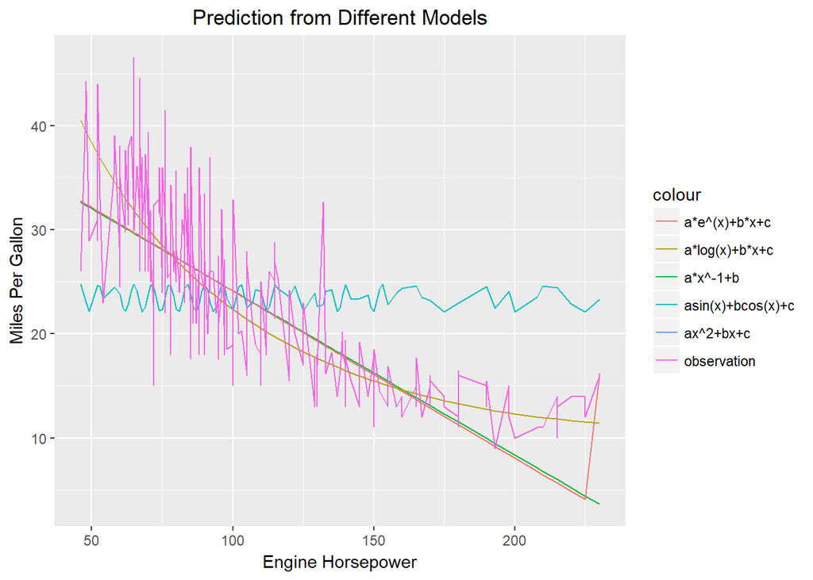

```r
library(ggplot2)
# mpg = a * horsepower + b
fit1 <- lm(data=dat, mpg~horsepower^2 + horsepower)
fit1.predict <- predict(fit1, newdata=dat)

# mpg = a * horsepower^-1 + b
fit2 <- lm(data=dat, mpg~1 / horsepower + horsepower)
fit2.predict <- predict(fit2, newdata=dat)

# mpg = a * e^(horsepower) + b * horsepower + c
fit3 <- lm(data=dat, mpg~exp(horsepower) + horsepower)
fit3.predict <- predict(fit3, newdata=dat)

# mpg = alog(horsepower) + b * horsepower + c
fit4 <- lm(data=dat, mpg~log(horsepower) + horsepower)
fit4.predict <- predict(fit4, newdata=dat)

# mpg = asin(horsepower) + bcos(horsepower) + c
fit5 <- lm(data=dat, mpg~sin(horsepower) + cos(horsepower))
fit5.predict <- predict(fit5, newdata=dat)


p <- ggplot() + geom_line(aes(dat$horsepower, fit1.predict, color= 'ax^2+bx+c')) +
  geom_line(aes(dat$horsepower, fit2.predict, color='a*x^-1+b')) +
  geom_line(aes(dat$horsepower, fit3.predict, color='a*e^(x)+b*x+c')) +
  geom_line(aes(dat$horsepower, fit4.predict, color='a*log(x)+b*x+c')) +
  geom_line(aes(dat$horsepower, fit5.predict, color='asin(x)+bcos(x)+c')) +
  geom_line(aes(dat$horsepower, dat$mpg, color='observation')) +
  xlab('Engine Horsepower') + ylab('Miles Per Gallon') +
  ggtitle('Prediction from Different Models') +
  theme(plot.title=element_text(hjust=0.5))
p
```

From the plot, we can see that in fact none of the models has an acceptable result. In general, the $alog(x) + bx + c$ function has a relatively better result.

3. Now fit a model to predict `mpg` using `horsepower`, `origin` and an interaction between them.

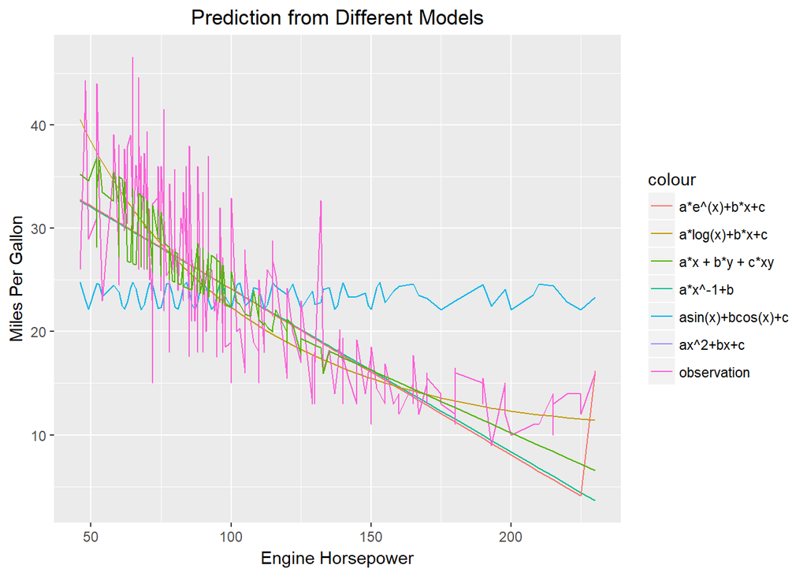

```r
fit.model <- lm(data=dat, mpg ~ horsepower + origin.f + origin.f * horsepower)
fit.predict <- predict(fit.model, newdata=dat)
p + geom_line(aes(dat$horsepower, fit.predict, color='a*x + b*y + c*xy'))
```

```r
summary(fit.model)
```

```
##
## Call:
## lm(formula = mpg ~ horsepower + origin.f + origin.f * horsepower,
##     data = dat)
##
## Residuals:
##      Min       1Q   Median       3Q      Max
## -10.7415  -2.9547  -0.6389   2.3978  14.2495
##
## Coefficients:
##                              Estimate Std. Error t value Pr(>|t|)
## (Intercept)                 34.476496   0.890665  38.709  < 2e-16 ***
## horsepower                  -0.121320   0.007095 -17.099  < 2e-16 ***
## origin.fEuropean            10.997230   2.396209   4.589 6.02e-06 ***
## origin.fJapanese            14.339718   2.464293   5.819 1.24e-08 ***
## horsepower:origin.fEuropean -0.100515   0.027723  -3.626 0.000327 ***
## horsepower:origin.fJapanese -0.108723   0.028980  -3.752 0.000203 ***
## ---
## Signif. codes:  0 '***' 0.001 '**' 0.01 '*' 0.05 '.' 0.1 ' ' 1
##
## Residual standard error: 4.422 on 386 degrees of freedom
## Multiple R-squared:  0.6831, Adjusted R-squared:  0.679
## F-statistic: 166.4 on 5 and 386 DF,  p-value: < 2.2e-16
```

5. Consider fitting a model to predict credit card `balance` using `income` and `student`, where `student` is a quantative variable that takes on one of three values
1. Encode the student variable using two dummy variables, one of which equals $1$ if `student=graduate` (and 0 otherwise), and one of which equals $1$ is `student=undergraduate` (and 0 otherwise). Write out an expression for a linear model to predict `balance` using `income` and `student`, using this coding of dummy variables.

```r
library(dplyr)
dat <- Credit

students <- which(dat$Student == "Yes")
dat$NotStudent <- 1
dat$NotStudent[students] <- 0
dat$NotStudent <- factor(dat$NotStudent)

# Graduate: years of education is greater than 16
dat$Graduate <- 0
graduates <- students[dat$Education >= 16]
under <- students[!(students %in% graduates)]

dat$Graduate[graduates] <- 1
dat$Graduate <- factor(dat$Graduate)

dat$Undergraduate <- 0
dat$Undergraduate[under] <- 1
dat$Undergraduate <- factor(dat$Undergraduate)


dat_a <- dat%>% select(Balance, Income, Graduate, Undergraduate)

model.fit_a <- lm(data=dat_a, Balance ~ .)

summary(model.fit_a)
```

```
##
## Call:
## lm(formula = Balance ~ ., data = dat_a)
##
## Residuals:
##     Min      1Q  Median      3Q     Max
## -762.21 -331.47  -44.35  323.58  818.34
##
## Coefficients:
##                Estimate Std. Error t value Pr(>|t|)
## (Intercept)    211.2992    32.5139   6.499 2.44e-10 ***
## Income           5.9809     0.5578  10.722  < 2e-16 ***
## Graduate1      366.5230   125.7985   2.914  0.00378 **
## Undergraduate1 388.0637    74.5947   5.202 3.17e-07 ***
## ---
## Signif. codes:  0 '***' 0.001 '**' 0.01 '*' 0.05 '.' 0.1 ' ' 1
##
## Residual standard error: 392.3 on 396 degrees of freedom
## Multiple R-squared:  0.2775, Adjusted R-squared:  0.272
## F-statistic:  50.7 on 3 and 396 DF,  p-value: < 2.2e-16
```

2. Now encode the student variable using two dummy variables, one of which equals $1$ if `student=not student` (and 0 otherwise), and one of which equals $1$ is `student=graduate` (and 0 otherwise). Write out an expression for a linear model to predict `balance` using `income` and `student`, using this coding of dummy variables.

```r
dat_b <- dat%>% select(Balance, Income, NotStudent, Graduate)

model.fit_b <- lm(data=dat_b, Balance ~ .)

summary(model.fit_b)
```

```
##
## Call:
## lm(formula = Balance ~ ., data = dat_b)
##
## Residuals:
##     Min      1Q  Median      3Q     Max
## -762.21 -331.47  -44.35  323.58  818.34
##
## Coefficients:
##              Estimate Std. Error t value Pr(>|t|)
## (Intercept)  599.3629    76.8483   7.799 5.57e-14 ***
## Income         5.9809     0.5578  10.722  < 2e-16 ***
## NotStudent1 -388.0637    74.5947  -5.202 3.17e-07 ***
## Graduate1    -21.5407   143.3608  -0.150    0.881
## ---
## Signif. codes:  0 '***' 0.001 '**' 0.01 '*' 0.05 '.' 0.1 ' ' 1
##
## Residual standard error: 392.3 on 396 degrees of freedom
## Multiple R-squared:  0.2775, Adjusted R-squared:  0.272
## F-statistic:  50.7 on 3 and 396 DF,  p-value: < 2.2e-16
```

3. Using the coding in (a), write out an expression for a linear model to predict `balance` using `income`, `student` and interaction between `income` and `student`.

```r
dat_c <- dat%>% select(Balance, Income, Graduate, Undergraduate)

model.fit_c <- lm(data=dat_c, Balance ~ . + Income*Graduate + Income*Undergraduate)

summary(model.fit_c)
```

```
##
## Call:
## lm(formula = Balance ~ . + Income * Graduate + Income * Undergraduate,
##     data = dat_c)
##
## Residuals:
##     Min      1Q  Median      3Q     Max
## -773.39 -325.70  -41.13  321.65  814.04
##
## Coefficients:
##                       Estimate Std. Error t value Pr(>|t|)
## (Intercept)           200.6232    33.7788   5.939 6.29e-09 ***
## Income                  6.2182     0.5935  10.477  < 2e-16 ***
## Graduate1             420.6187   206.1444   2.040    0.042 *
## Undergraduate1        496.3933   119.5927   4.151 4.06e-05 ***
## Income:Graduate1       -1.3420     4.1408  -0.324    0.746
## Income:Undergraduate1  -2.1922     1.8889  -1.161    0.247
## ---
## Signif. codes:  0 '***' 0.001 '**' 0.01 '*' 0.05 '.' 0.1 ' ' 1
##
## Residual standard error: 392.6 on 394 degrees of freedom
## Multiple R-squared:  0.2801, Adjusted R-squared:  0.271
## F-statistic: 30.66 on 5 and 394 DF,  p-value: < 2.2e-16
```

4. Using the coding in (b), write out an expression for a linear model to predict `balance` using `income`, `student` and interaction between `income` and `student`.

```r
dat_d <- dat%>% select(Balance, Income, Graduate, NotStudent)

model.fit_d <- lm(data=dat_d, Balance ~ . + Income*Graduate + Income*NotStudent)

summary(model.fit_d)
```

```
##
## Call:
## lm(formula = Balance ~ . + Income * Graduate + Income * NotStudent,
##     data = dat_d)
##
## Residuals:
##     Min      1Q  Median      3Q     Max
## -773.39 -325.70  -41.13  321.65  814.04
##
## Coefficients:
##                     Estimate Std. Error t value Pr(>|t|)
## (Intercept)         697.0165   114.7232   6.076 2.91e-09 ***
## Income                4.0260     1.7932   2.245   0.0253 *
## Graduate1           -75.7746   233.4865  -0.325   0.7457
## NotStudent1        -496.3933   119.5927  -4.151 4.06e-05 ***
## Income:Graduate1      0.8502     4.4732   0.190   0.8494
## Income:NotStudent1    2.1922     1.8889   1.161   0.2465
## ---
## Signif. codes:  0 '***' 0.001 '**' 0.01 '*' 0.05 '.' 0.1 ' ' 1
##
## Residual standard error: 392.6 on 394 degrees of freedom
## Multiple R-squared:  0.2801, Adjusted R-squared:  0.271
## F-statistic: 30.66 on 5 and 394 DF,  p-value: < 2.2e-16
```

5. Using simulated data to show that the fitted values from the models in (a) - (d) do not depend on the coding of the dummy variables.

```r
dat<- dat%>% select(Balance, Income, Graduate, NotStudent, Undergraduate)
model.predict_a <- predict(model.fit_a, newdata=dat)
model.predict_b <- predict(model.fit_b, newdata=dat)
model.predict_c <- predict(model.fit_c, newdata=dat)
model.predict_d <- predict(model.fit_d, newdata=dat)
```

We want to see if the predictions are identical. Set the tolerence to be $10^{-10}$

```r
tol = 1e-10
any(abs(model.predict_a - model.predict_b) > tol)
```

```
## [1] FALSE
```

So we know that the prediction from the model in part(a) is identical with the model in part(b). Similarly, we have

```r
any(abs(model.predict_c - model.predict_d) > tol)
```

```
## [1] FALSE
```

So the prediction from the model in part(c) is also identical with the model in part(d).